# Practical_ML_Assignment

Aman Jha

1/11/2020

The libraries used are as follows:-

```r
library(dplyr)
library(caret)
library(randomForest)
```

```r
library(rpart.plot)
```

## Summary

Here we are trying to classify whether a subject is performing an exercise correctly.We take a dumbell curl dataset and try to predict all properties required to perform such an exercise correctly.This data is provided through band-type devices.The class we are going to predict here are **classe**

The classes are :- **A(the correct way )** and **B,C,D,E(incorrect ones)**

## Reading and preprocessing

Here we are using the **pml-training.csv** and **pml-testing.csv**.This can be downloaded from:-

https://d396qusza40orc.cloudfront.net/predmachlearn/pml-training.csv

https://d396qusza40orc.cloudfront.net/predmachlearn/pml-testing.csv

```r
set.seed(34234)
training<- read.csv("pml-training.csv")
testing<- read.csv("pml-testing.csv")
```

As we are just using the readings from the accelerometer on the belt, forearm, arm, and dumbell of 6 participants, we can eliminate the following variables:-

### Removing variables with more 95% data as NA

```r
index<- which((colSums(is.na(training))/nrow(training)<0.95)==TRUE)
clean_training_data<- training[,index]
clean_testing_data<- testing[,index]
```

### Removing columns which are not required

The dataset we need requires only selected variables thus we can remove columns involving kurtosis,skweness,amplitude etc.

```r
cols<- c("^kurtosis","^skewness","^max","^min","^amplitude")
fake_index<- grep(paste(cols,collapse="|"),names(clean_training_data),value=FALSE)
clean_training_data<- clean_training_data[,-fake_index]
clean_testing_data<- clean_testing_data[,-fake_index]
```

We also remove the first 7 variables as they have no relation with the **classe** variable.

```r
clean_training_data<- clean_training_data[,-(1:7)]
clean_testing_data<- clean_testing_data[,-(1:7)]
```

## Creating training & test sets (Cross Validation )

Assembling 75% of the data for trainingand rest for testing.We also set up a cross validation control for the given training models discussed below.

```r
inTrain<- createDataPartition(clean_training_data$classe,p=0.75,list=FALSE)
trainset<-clean_training_data[inTrain,]
testset<-clean_training_data[-inTrain,]
control<- trainControl(method="repeatedcv",number =10,repeats = 3)
```

## Setting up models

### MODEL 1:- Decision Trees

We fit a tree in the above training set and match it with the validation test set

```r
fit1<- train(classe~.,trainset,method="rpart",trControl=control)
pred1<- predict(fit1,testset)
confusionMatrix(pred1,testset$classe)
```

```
## Confusion Matrix and Statistics
##
##           Reference
## Prediction    A    B    C    D    E
##          A 1271  412  388  357  129
##          B   21  309   24  142  126
##          C  100  228  443  305  237
##          D    0    0    0    0    0
##          E    3    0    0    0  409
##
## Overall Statistics
##
##                Accuracy : 0.4959
##                  95% CI : (0.4818, 0.51)
##     No Information Rate : 0.2845
##     P-Value [Acc > NIR] : < 2.2e-16
##
##                   Kappa : 0.3411
##
##  Mcnemar's Test P-Value : NA
##
## Statistics by Class:
##
##                      Class: A Class: B Class: C Class: D Class: E
## Sensitivity            0.9111  0.32561  0.51813   0.0000  0.45394
## Specificity            0.6335  0.92086  0.78513   1.0000  0.99925
## Pos Pred Value         0.4971  0.49678  0.33740      NaN  0.99272
## Neg Pred Value         0.9472  0.85054  0.88527   0.8361  0.89047
## Prevalence             0.2845  0.19352  0.17435   0.1639  0.18373
## Detection Rate         0.2592  0.06301  0.09033   0.0000  0.08340
## Detection Prevalence   0.5214  0.12684  0.26774   0.0000  0.08401
## Balanced Accuracy      0.7723  0.62323  0.65163   0.5000  0.72660
```

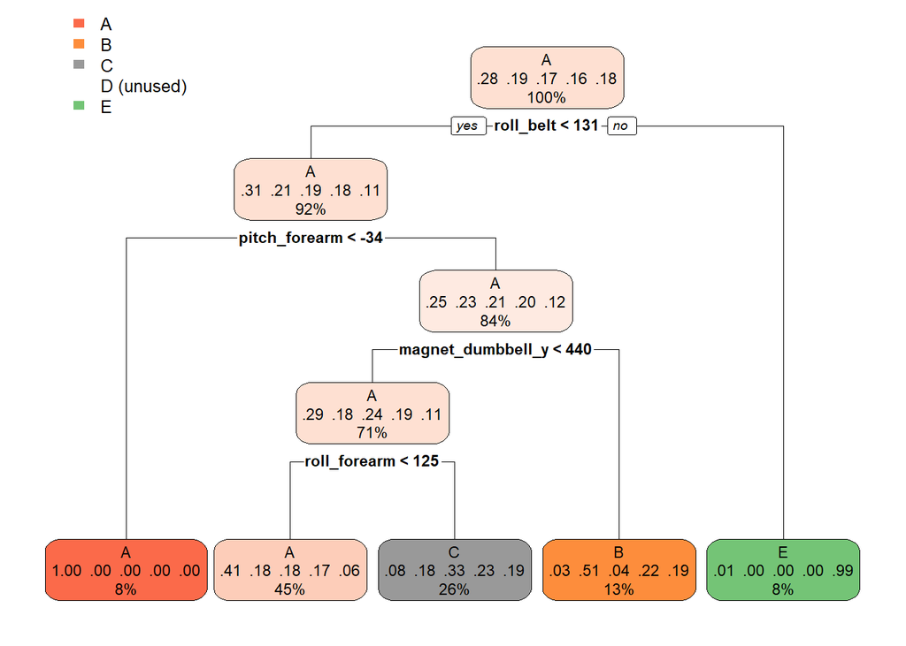

```r
rpart.plot(fit1$finalModel)
```

### MODEL 2:- Random Forests

We check for random forests here .

```r
fit2<- randomForest(classe~.,data = trainset)
pred2<- predict(fit2,testset)
rf_matrix<- confusionMatrix(pred2,testset$classe)
rf_matrix
```

```
## Confusion Matrix and Statistics
##
##           Reference
## Prediction    A    B    C    D    E
##          A 1393    6    0    0    0
##          B    2  941    4    0    0
##          C    0    2  848    7    0
##          D    0    0    3  796    3
##          E    0    0    0    1  898
##
## Overall Statistics
##
##                Accuracy : 0.9943
##                  95% CI : (0.9918, 0.9962)
##     No Information Rate : 0.2845
##     P-Value [Acc > NIR] : < 2.2e-16
##
##                   Kappa : 0.9928
##
##  Mcnemar's Test P-Value : NA
##
## Statistics by Class:
##
##                      Class: A Class: B Class: C Class: D Class: E
## Sensitivity            0.9986   0.9916   0.9918   0.9900   0.9967
## Specificity            0.9983   0.9985   0.9978   0.9985   0.9998
## Pos Pred Value         0.9957   0.9937   0.9895   0.9925   0.9989
## Neg Pred Value         0.9994   0.9980   0.9983   0.9980   0.9993
## Prevalence             0.2845   0.1935   0.1743   0.1639   0.1837
## Detection Rate         0.2841   0.1919   0.1729   0.1623   0.1831
## Detection Prevalence   0.2853   0.1931   0.1748   0.1635   0.1833
## Balanced Accuracy      0.9984   0.9950   0.9948   0.9943   0.9982
```

We can see the accuracy is 99% which makes rf the clear choice.

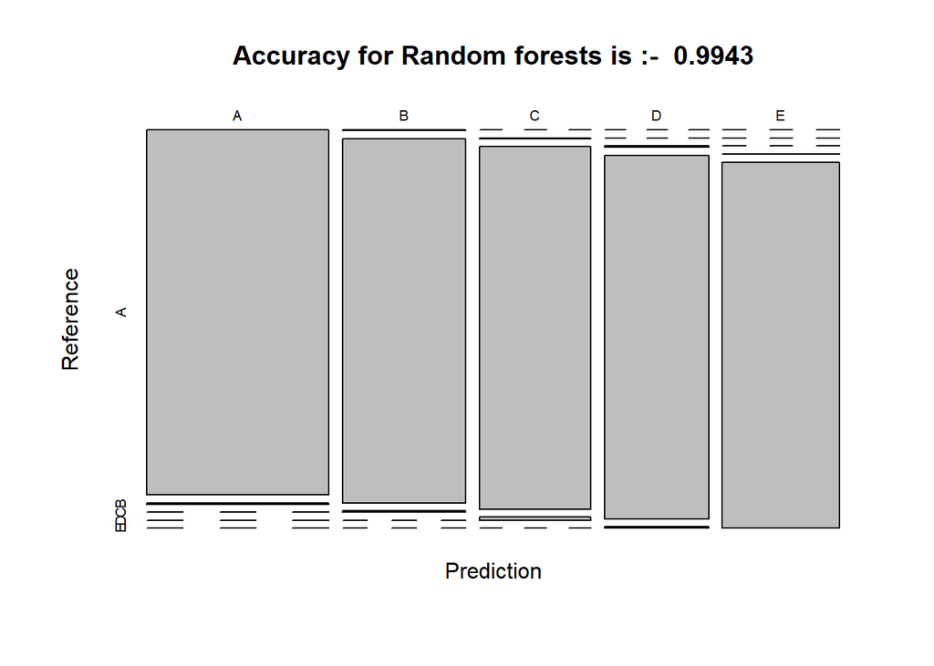

```r
plot(rf_matrix$table,main=paste("Accuracy for Random forests is :- ", round(rf_matrix$overall[[1]],4)))
```

## Conclusion

We see that **Random forest model** is almost perfect for this dataset.

THus predicting the testing data we have:-

```r
predict(fit2,newdata=testing)
```

```
##  1  2  3  4  5  6  7  8  9 10 11 12 13 14 15 16 17 18 19 20
##  B  A  B  A  A  E  D  B  A  A  B  C  B  A  E  E  A  B  B  B
## Levels: A B C D E
```